# Evaluation of an Emprirical MP for East Atlantic and Mediterranean Bluefin

Conditioning of Operating Model

Laurence Kell

21/03/2015

# Operating Model

## Scenarios

Scenarios used for the OM were based on the 2014 stock assessment and the cross-validation (**Figure** 1). Due to the lack of convergence in the VPA and the changes catchability and relative fishing mortality-at-age in due to management in recent years the series was tuncated to end in 2008.

A sequential t-test algorithm (STARS; rodionov, 2004 as modified by Szuwalski et al., 2014) was used to identify regime shifts in recruitment (**Figure** 2). The OM was conditioned so that mass, m, proportion mature and selectivity-at-age from 2009 onwards was the average from years 2006 to 2008 (**Figure** 3 shows the corresponding equilibrium curves). Recruitment in the most recent regime (1999 onwards) was given by the estimates from STARS (**Figure** 4).

70% of FMSY is often cited as a target F. Although it will be impossible to implement in practice it does provide a basis for comparison, i.e. a counterfacual run against which simulation trials can be compared. Therefore all scenarios were projected from 2009 to 2050 for an F of 70% of FMSY (**Figure** 5).

# Management Procedure

An empirical MP has already been run (SCRS2014-36). The issues are

- Do we also want to run a VPA MP?
- What goes in the observation error model? I was going to use the cross-validation paper to propose CPUE time series, then propose some aerial survey time series with a range of CVs due to measurement and process error.
- What about CAA? the VPA is based on age slicing which we know is biased. Do we ignore this or include ageing error in the conditioning of the OM?

# Figures

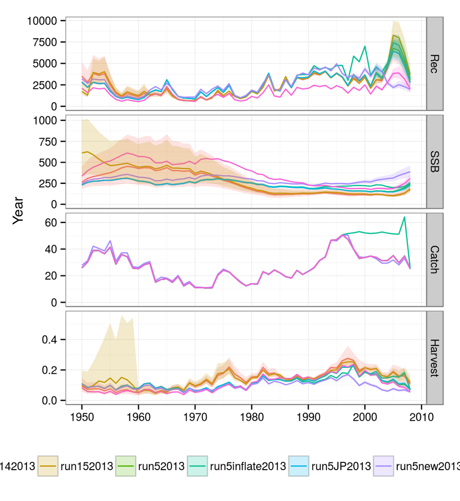

**Figure 1** Time series of recruitment, SSB, catch and fishing mortality by scenario.

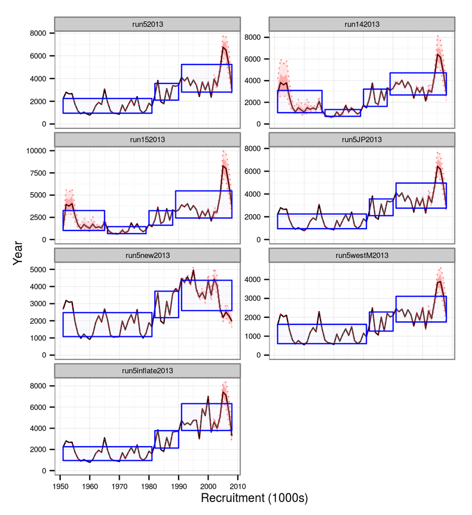

**Figure 2** Time series of recruitment with regimes estimated by STARS algorithm by scenario

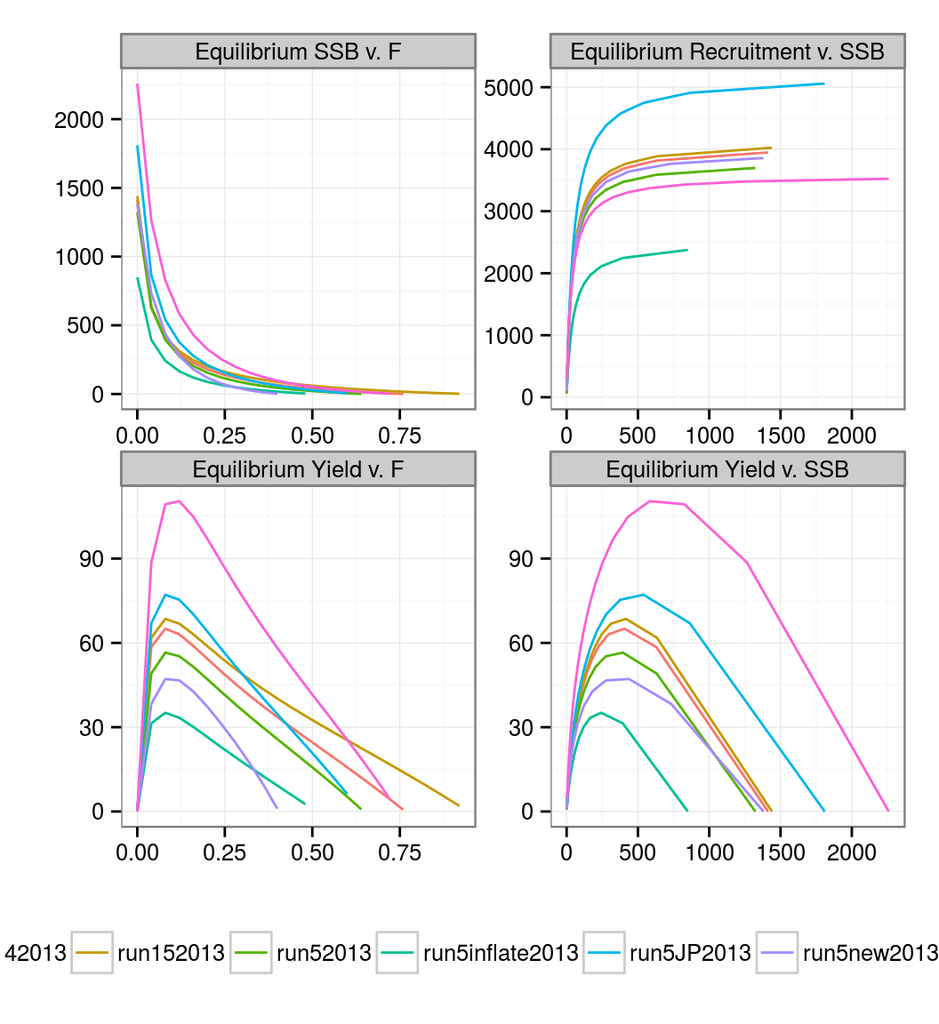

**Figure 3** Equilibrium curves by scenario

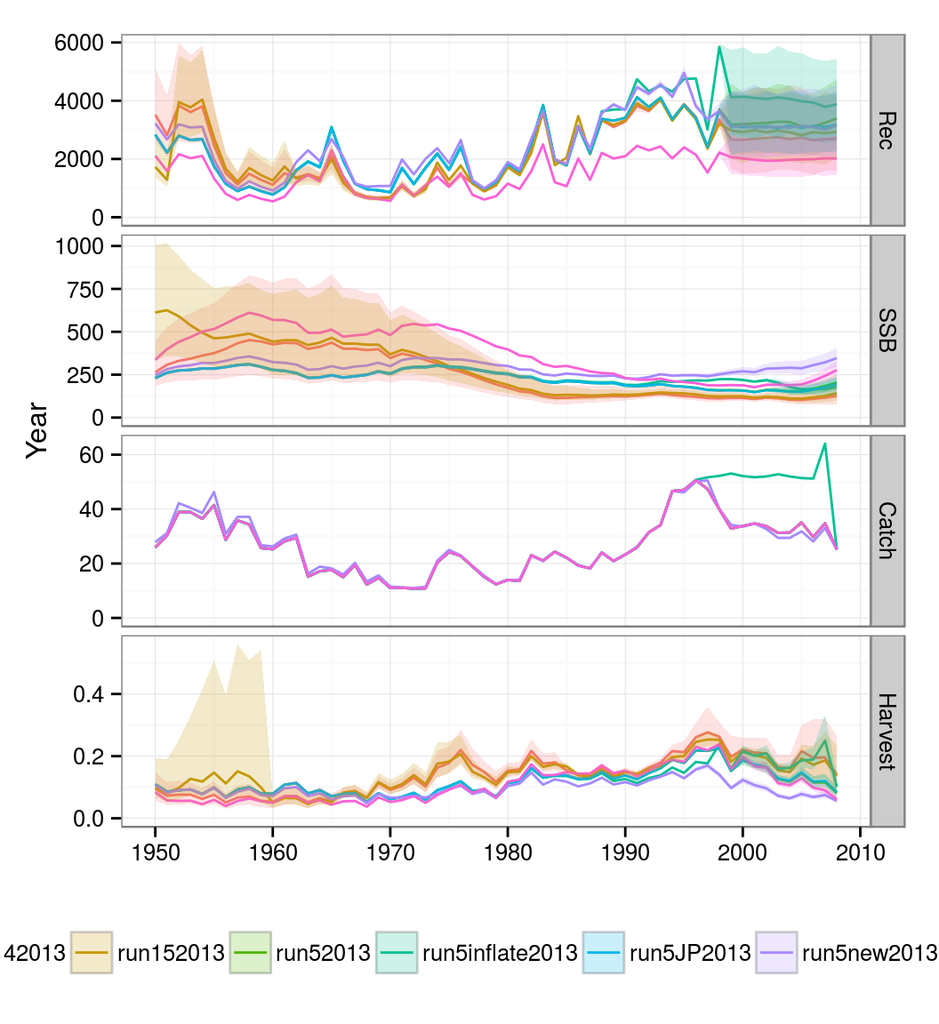

**Figure 4** Time series of recruitment, SSB, catch and fishing mortality by scenario; values from 1999 are generated with gamma recruitment deviates sith mean and variance estimated by STARS, projected for observered catches.

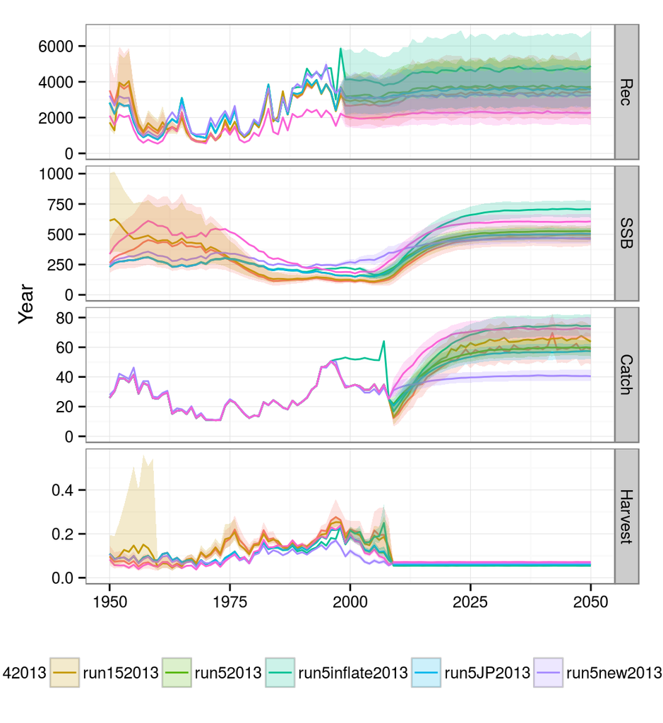

**Figure 5** Counterfactual time series of recruitment, SSB, catch and fishing mortality by scenario; values from 1999 are generated with gamma recruitment deviates sith mean and variance estimated by STARS, projected for observered catches up to 2008 and for F=70% of FMSY upto 2050.